# P for POWER

02/01/2021

## R4.0 Environment

*library(knitr)* creating slides

*library(ggplot2)* making plots

*library(reshape2)* # for data frames

## POWER

Power is the probability of rejecting the NULL HYPOTHESIS when it is false.

:: Power is used to determine if your sample size was big enough to yield a meaningful, rather than random, result

:: Detect if your ALTERNATIVE hypothesis is true, to lower the risk of a Type II errors.

## Equation

As beta is the probability of a *Type II error, for accepting* *a false null hypothesis*, and the complement of this is (1-\(\beta\)), the power is:

\[ P = (1-\beta) \]

## Sleep Example

:: H_0 mu = 30

:: H_a mu > 30

where (X’-30)/(s/\(\sqrt(n)\)) measures the number of standard errors the sample mean is from the mean hypothesized by H_0 and the denominator, (s/\(\sqrt(n)\)) is the standard error of the sample mean.

## Alpha

Power is the probability that the true mean mu is greater than the (1-\(\alpha\)) quantile

:: if \(\alpha\) = .05 and as H_a mu > 30

:: for normal distributions of which we know the variances:

P = qnorm(.95)

## When to reject H_0 ?

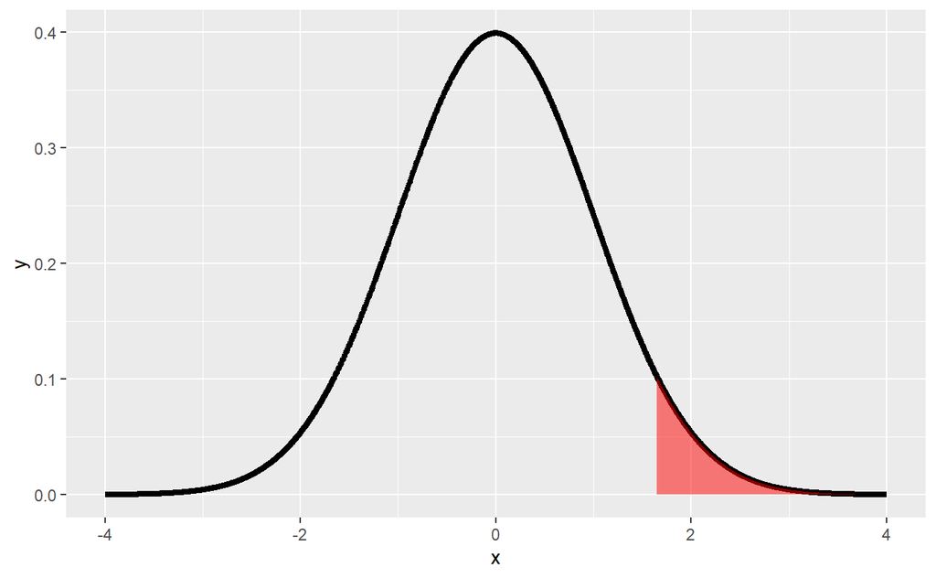

If a test statistic fell in the shaded portion, 5% of the area under the curve, we would reject H_0 and favor H_a.

## Two distributions

The two hypotheses, H_0 and H_a, represent two distributions

:: since they’re talking about means or

:: centers of distributions.

## Normal distributed

For a *random variable* X which is distributed as *Normal* with a mean *mu* (μ) and variance *sigma squared* (σ2)

:: under H_0, X’ N(\(\mu_0\) , \(\sigma^2\)/n)

:: under H_a, X’ N(\(\mu_a\) , \(\sigma^2\)/n)

## 95th percentile of H_0, in red

## Mean proposed by H_a, in blue

## POWER is how far H_a is right of 95th percentile of H_0

## Power depends on the null distribution

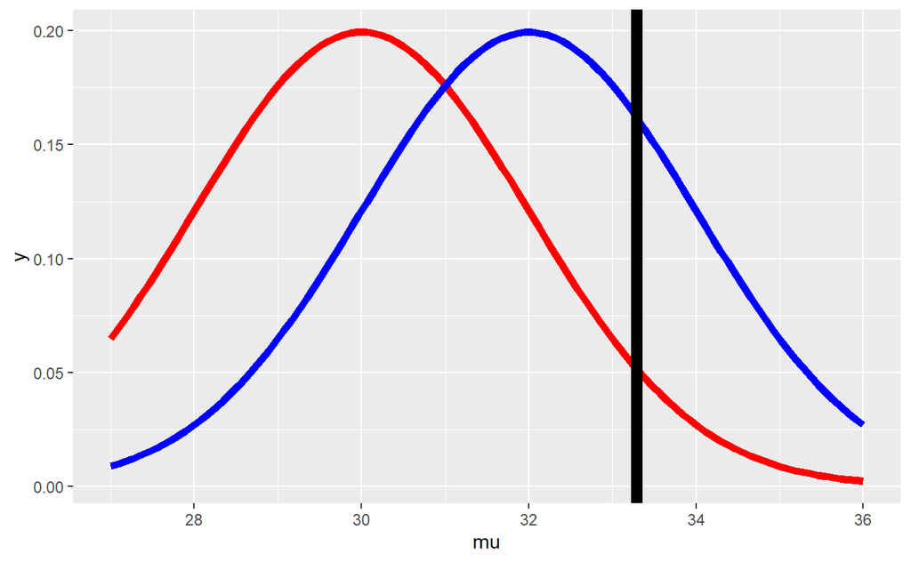

## If \(\mu_a\) = 34, the test is more powerful

:: correct to reject the null hypothesis since it appears false.

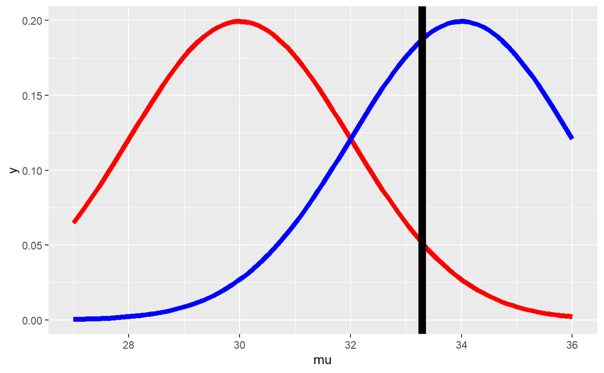

## If \(\mu_a\) = 30, the power = \(\alpha\)

The distribution represented by H_a will move under the blue curve, indicating that with \(\mu_a\) = 30 = \(\mu_0\) 4, the test is as powerful as the H_0.

:: in correct to reject the null hypothesis since it appears not false.

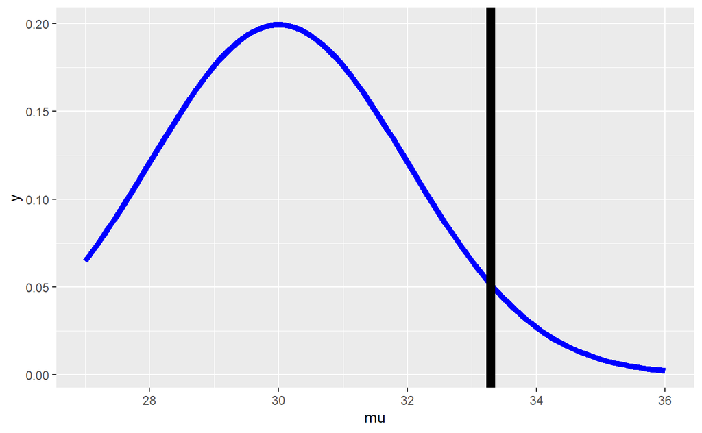

## If \(\mu_a\) = 28, the power is weaker

The distribution represented by H_a will move to the left of \(\mu_0\) = 30, the area under the blue curve is less than the 5% so the test is less powerful and contradicts H_a.

:: it’s not worth looking at

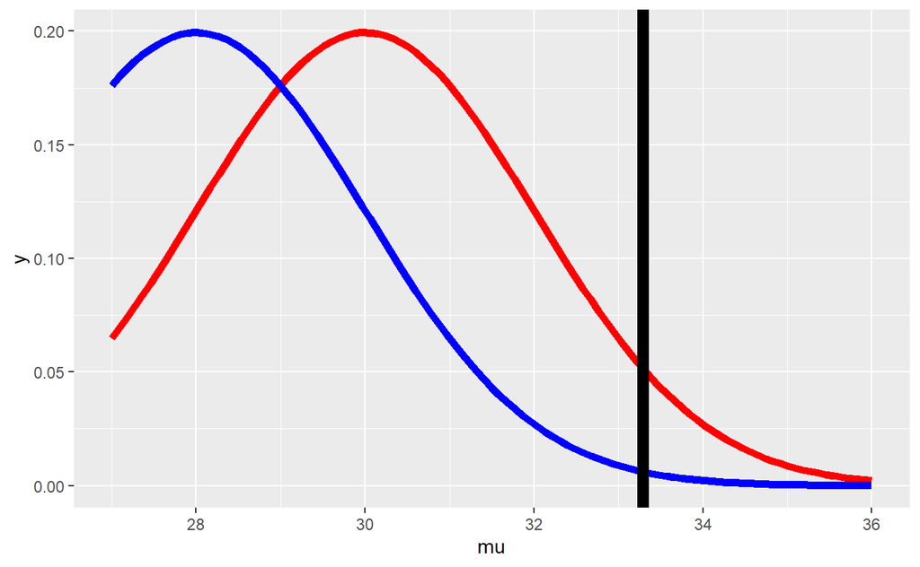

## RECAP

Power is a function that depends on a specific value of an alternative mean, mu_a, which is any value greater than mu_0, the mean hypothesized by H_0.

:: Recall that H_a specified mu > 30.

## RECAP

If mu_a is much bigger than mu_0=30 then the power (probability) is bigger than if mu_a is close to 30.

:: As mu_a approaches 30, the mean under H_0, the power approaches alpha.

## RECAP

:: As \(\mu_a\) gets bigger, it gets more powerful

:: As \(n\) gets bigger, it gets more powerful

## Power Curves \(n\)

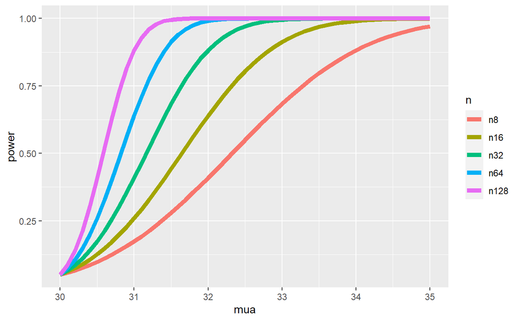

## z <- qnorm(.95)

```r
z <- qnorm(.95)

pnorm(30+z,mean=30,lower.tail=FALSE)
```

```
## [1] 0.05
```

With the mean set to mu_0 the two distributions, null and alternative, are the same and power=alpha.

## \(\mu_a\) > \(\mu_0\)

```r
z <- qnorm(.95)

pnorm(30+z, mean=32,lower.tail=FALSE)
```

```
## [1] 0.63876
```

With \(\mu_a\) > \(\mu_0\)mu_a the power is at 64% as opposed to 5%.

:: When the sample mean is many standard errors greater than the mean hypothesized by the null hypothesis,

:: the probability of rejecting H_0 when it is false is much higher.

## Standard deviation, sd

when \(sd\) = 1

```r
z <- qnorm(.95)

pnorm(30+z, mean=32, sd= 1, lower.tail=FALSE)
```

```
## [1] 0.63876
```

when \(sd\) = 2

```r
z <- qnorm(.95)

pnorm(30+z, mean=32, sd= 2, lower.tail=FALSE)
```

```
## [1] 0.5704709
```

:: Power decreases with increases in variation

## Power Curves \(\sigma\)

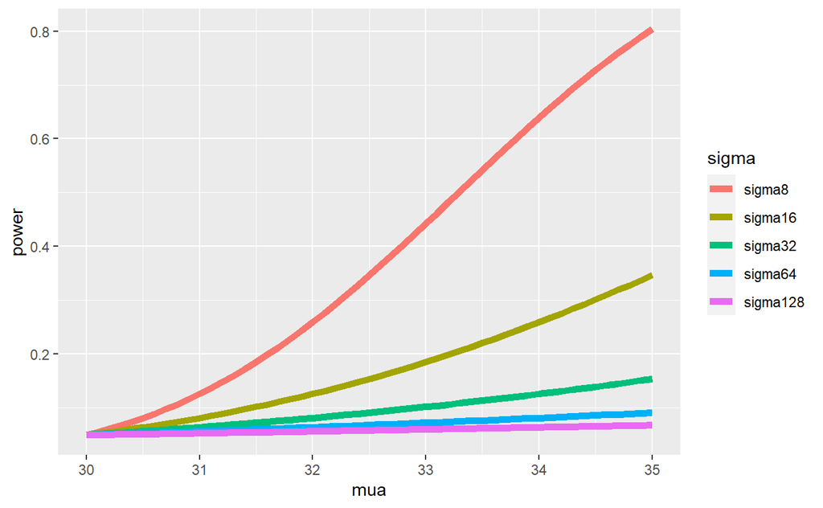

## RECAP

:: As \(\alpha\) increases, power increases

:: In a one sided test the power is greater as \(\alpha\) is bigger than \(\alpha\)/2

## Power Curves \(\alpha\)

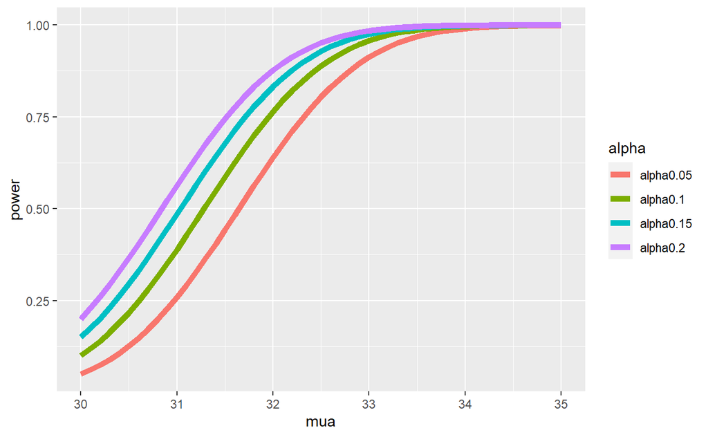

## if H_a specified that \(\mu\) < \(\mu_0\)

:: flip the above reasoning

## RECAP

Suppose H_a says that mu > mu_0. :: power = 1 - beta

= Prob ( X’ > mu_0 + z_(1-alpha) * sigma/sqrt(n))

assuming that X’~ N(mu_a,sigma^2/n).

:: given the context of the problem, …

## for H_a says that mu > mu_0 we know

:: the population mean equals \(\mu_0\)

:: the level size of the test is \(\alpha\)

## \(\beta\), \(\sigma\), \(n\), and \(\mu_a\)

In the statement 1 - beta

= Prob( X’ > mu_0 + z_(1-alpha) * sigma/sqrt(n))

:: Given \(\mu_a\) > \(\mu_0\), \(\mu_0\) and \(\alpha\) are specified, :: and X’ depends on the data.

:: The other four quantities, (\(\beta\), \(\sigma\), \(n\), and \(\mu_a\)) are all unknown.

## Solve for \(P\) (power) or \(n\) (sample size)

:: only \(\sqrt(n)\) * \(\frac{\mu_a - \mu_0}{\sigma}\) is needed

:: this is the effect size

## Example: t distributions

:: t quantile instead of the z

Power is still a probability, namely :: \(\frac{P(X' - \mu_0)}{(S /\sqrt(n)}\) > t_(1-\(\alpha\), \(n\)-1) for H_a that mu > mu_a

:: the proposed distribution is not centered at mu_0, :: have to use the non-central t distribution.

## R functipon power.t.test()

:: omit one of the arguments and power.t.test() solves for it

```r
power.t.test(n = 16,delta = 2 / 4, sd=1, type = "one.sample",
             alt = "one.sided")$power
```

```
## [1] 0.6040329
```

```r
power.t.test(n = 16, delta = 2 , sd=4, type = "one.sample",
             alt ="one.sided")$power
```

```
## [1] 0.6040329
```

```r
power.t.test(n = 16, delta = 100 , sd=200, type = "one.sample",
             alt ="one.sided")$power
```

```
## [1] 0.6040329
```

## Constant POWER

:: keeping the effect size (the ratio delta/sd) constant preserved the power

:: get a constant effect size with

*with the same values for n (16) & alpha (.05), but* *different delta and standard deviation values*

## Solve for \(n\)

:: specify a power we want and solve for the sample size \(n\).

```r
power.t.test(power = .8, delta = 2 / 4, sd=1, type = "one.sample",
             alt = "one.sided")$n
```

```
## [1] 26.13751
```

```r
power.t.test(power = .8, delta = 2, sd=4, type = "one.sample",
             alt = "one.sided")$n
```

```
## [1] 26.13751
```

```r
power.t.test(power = .8, delta = 100, sd=200, type = "one.sample",
             alt = "one.sided")$n
```

```
## [1] 26.13751
```

## Solve for \(\delta\) change \(n\)

:: use power.t.test to find delta for a power=.8 and n=26 and sd=1

```r
power.t.test(power = .8, n=26, sd=1, type = "one.sample",
             alt = "one.sided")$delta
```

```
## [1] 0.5013986
```

:: use power.t.test to find delta for a power=.8 and n=27 and sd=1

```r
power.t.test(power = .8, n=27, sd=1, type = "one.sample",
             alt = "one.sided")$delta
```

```
## [1] 0.4914855
```

## Solve for \(\delta\) change \(sd\)

:: use power.t.test to find delta for a power=.8 and n=26 and sd=2

```r
power.t.test(power = .8, n=26, sd=2, type = "one.sample",
             alt = "one.sided")$delta
```

```
## [1] 1.002797
```

[Plots from swirl repo](https://github.com/swirldev/swirl_courses)